# STA2201_Lab2

Alice Huang

18/01/2023

# Downloading packages and data

```r
library(opendatatoronto)
library(tidyverse)
library(stringr)
library(skimr) # EDA
library(visdat) # EDA
library(janitor)
library(lubridate)
library(ggrepel)

all_data <- list_packages(limit = 500)

res <- list_package_resources("996cfe8d-fb35-40ce-b569-698d51fc683b") # obtained code from searching data frame above
res <- res %>% mutate(year = str_extract(name, "202.?"))
delay_2022_ids <- res %>% filter(year==2022) %>% select(id) %>% pull()

delay_2022 <- get_resource(delay_2022_ids)

# make the column names nicer to work with
delay_2022 <- clean_names(delay_2022)

# note: I obtained these codes from the 'id' column in the `res` object above
delay_codes <- get_resource("3900e649-f31e-4b79-9f20-4731bbfd94f7")
delay_data_codebook <- get_resource("ca43ac3d-3940-4315-889b-a9375e7b8aa4")
```

# Lab Exercises

To be handed in via submission of quarto file (and rendered pdf) to GitHub.

1. Using the `delay_2022` data, plot the five stations with the highest mean delays. Facet the graph by `line`

[figure not shown]

```r
delay_2022 %>%
  group_by(line, station) %>%
  summarise(mean_delay = mean(min_delay)) %>%
  arrange(-mean_delay) %>%
  slice(1:5) %>%
  ggplot(aes(x = station,
             y = mean_delay)) +
  geom_col() +
  facet_wrap(vars(line),
             scales = "free_y",
             nrow = 4) +
  coord_flip()
```

2. Using the `opendatatoronto` package, download the data on mayoral campaign contributions for 2014. Hints:
   - find the ID code you need for the package you need by searching for ‘campaign’ in the `all_data` tibble above
   - you will then need to `list_package_resources` to get ID for the data file
   - note: the 2014 file you will get from `get_resource` has a bunch of different campaign contributions, so just keep the data that relates to the Mayor election

```r
all_data %>% filter(title=="Elections - Campaign Contributions - 2014 to 2017") %>%
  select(id) %>% pull -> all_data_id

dflist <- list_package_resources(all_data_id) # obtained code from searching data frame above

camp2014 <- get_resource("5b230e92-0a22-4a15-9572-0b19cc222985")
mayorcamp2014 <- camp2014$`2_Mayor_Contributions_2014_election.xls`
```

3. Clean up the data format (fixing the parsing issue and standardizing the column names using `janitor`)

```r
row_to_names(mayorcamp2014, 1, TRUE, TRUE) -> mayorcamp2014
clean_names(mayorcamp2014) -> mayorcamp2014
head(mayorcamp2014)
```

| contributors_name | contributors_address | contributors_postal_code | contribution_amount | contribution_type_desc | goods_or_service_desc | contributor_type_desc | relationship_to_candidate | president_business_manager | authorized_representative | candidate | office | ward |
| --- | --- | --- | --- | --- | --- | --- | --- | --- | --- | --- | --- | --- |
| A D'Angelo, Tullio | NA | M6A 1P5 | 300 | Monetary | NA | Individual | NA | NA | NA | Ford, Rob | Mayor | NA |
| A Strazar, Martin | NA | M2M 3B8 | 300 | Monetary | NA | Individual | NA | NA | NA | Ford, Rob | Mayor | NA |
| A'Court, K Susan | NA | M4M 2J8 | 36 | Monetary | NA | Individual | NA | NA | NA | Chow, Olivia | Mayor | NA |
| A'Court, K Susan | NA | M4M 2J8 | 100 | Monetary | NA | Individual | NA | NA | NA | Chow, Olivia | Mayor | NA |
| A'Court, K Susan | NA | M4M 2J8 | 100 | Monetary | NA | Individual | NA | NA | NA | Chow, Olivia | Mayor | NA |
| Aaron, Robert B | NA | M6B 1H7 | 250 | Monetary | NA | Individual | NA | NA | NA | Tory, John | Mayor | NA |

4. Summarize the variables in the dataset. Are there missing values, and if so, should we be worried about them? Is every variable in the format it should be? If not, create new variable(s) that are in the right format.

```r
summary(mayorcamp2014)
```

```
##  contributors_name  contributors_address contributors_postal_code
##  Length:10199       Length:10199         Length:10199
##  Class :character   Class :character     Class :character
##  Mode  :character   Mode  :character     Mode  :character
##  contribution_amount contribution_type_desc goods_or_service_desc
##  Length:10199        Length:10199           Length:10199
##  Class :character    Class :character       Class :character
##  Mode  :character    Mode  :character       Mode  :character
##  contributor_type_desc relationship_to_candidate president_business_manager
##  Length:10199          Length:10199              Length:10199
##  Class :character      Class :character          Class :character
##  Mode  :character      Mode  :character          Mode  :character
##  authorized_representative  candidate            office
##  Length:10199              Length:10199       Length:10199
##  Class :character          Class :character   Class :character
##  Mode  :character          Mode  :character   Mode  :character
##      ward
##  Length:10199
##  Class :character
##  Mode  :character
```

```r
skim(mayorcamp2014)
```

Data summary

| Name | mayorcamp2014 |
| --- | --- |
| Number of rows | 10199 |
| Number of columns | 13 |
| _______________________ |  |
| Column type frequency: |  |
| character | 13 |
| ________________________ |  |
| Group variables | None |

**Variable type: character**

| skim_variable | n_missing | complete_rate | min | max | empty | n_unique | whitespace |
| --- | --- | --- | --- | --- | --- | --- | --- |
| contributors_name | 0 | 1 | 4 | 31 | 0 | 7545 | 0 |
| contributors_address | 10197 | 0 | 24 | 26 | 0 | 2 | 0 |
| contributors_postal_code | 0 | 1 | 7 | 7 | 0 | 5284 | 0 |
| contribution_amount | 0 | 1 | 1 | 18 | 0 | 209 | 0 |
| contribution_type_desc | 0 | 1 | 8 | 14 | 0 | 2 | 0 |
| goods_or_service_desc | 10188 | 0 | 11 | 40 | 0 | 9 | 0 |
| contributor_type_desc | 0 | 1 | 10 | 11 | 0 | 2 | 0 |
| relationship_to_candidate | 10166 | 0 | 6 | 9 | 0 | 2 | 0 |
| president_business_manager | 10197 | 0 | 13 | 16 | 0 | 2 | 0 |
| authorized_representative | 10197 | 0 | 13 | 16 | 0 | 2 | 0 |
| candidate | 0 | 1 | 9 | 18 | 0 | 27 | 0 |
| office | 0 | 1 | 5 | 5 | 0 | 1 | 0 |
| ward | 10199 | 0 | NA | NA | 0 | 0 | 0 |

There are 10197 missing values in `contributors_address` column. I wouldn’t be worried about this as this information was probably hidden for privacy reasons.

There are 10188 missing values in the `goods_or_service_desc` column. There are 10166 missing values in the `relationship_to_candidate` column. There are 10197 missing values in the `president_business_manager` column. There are 10197 missing values in the `authorized_representative` column and 10199 missing values in the `ward` column. This likely means that we will not be able to consider these variables with lots of missing data in our data analysis.

The contribution_amount variable is in character format, so we should change it to numeric format.

```r
mayorcamp2014$contribution_amount <- as.numeric(mayorcamp2014$contribution_amount)
```

5. Visually explore the distribution of values of the contributions. What contributions are notable outliers? Do they share a similar characteristic(s)? It may be useful to plot the distribution of contributions without these outliers to get a better sense of the majority of the data.

Here is the distribution of contribution amounts.

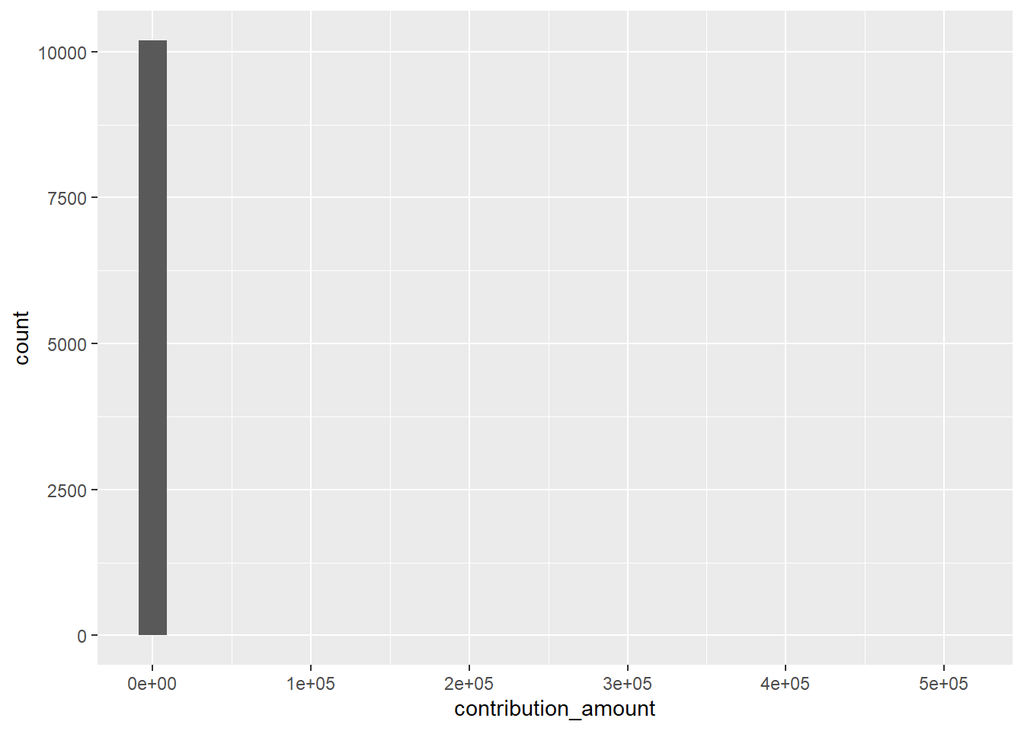

```r
mayorcamp2014 %>% ggplot(aes(x=contribution_amount)) + geom_histogram()
```

We notice that there are outliers in the contribution amount. Upon closer inspection of the data, it appears that the outliers are from candidates donating to their own campaign.

```r
mayorcamp2014 %>% arrange(desc(contribution_amount)) %>%
  select(contributors_name, contribution_amount, relationship_to_candidate) %>%
  slice(1:10)
```

| contributors_name | contribution_amount | relationship_to_candidate |
| --- | --- | --- |
| Ford, Doug | 508224.73 | Candidate |
| Ford, Rob | 78804.80 | Candidate |
| Ford, Doug | 50000.00 | Candidate |
| Ford, Rob | 50000.00 | Candidate |
| Ford, Rob | 50000.00 | Candidate |
| Goldkind, Ari | 23623.63 | Candidate |
| Ford, Rob | 20000.00 | Candidate |
| Ford, Rob | 12210.00 | Candidate |
| Di Paola, Rocco | 6000.00 | Candidate |
| Thomson, Sarah | 4425.55 | Candidate |

Let’s see what distribution looks like if we filter out instances where candidates donated to their own campaign. The amounts that candidates’ spouses donated were in the higher end, but they were not significantly higher than the rest of the donations, so I left them in there.

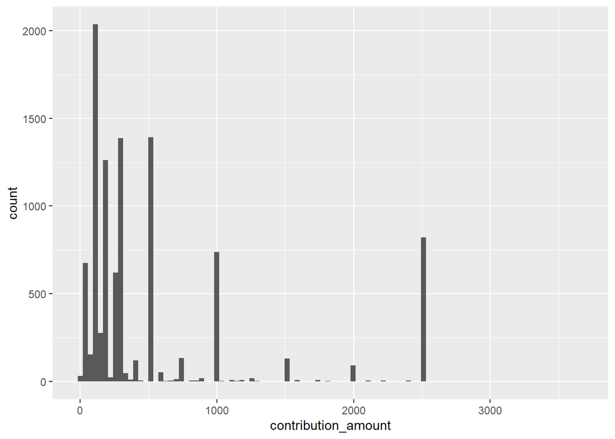

```r
cand_rels <- mayorcamp2014 %>% select(relationship_to_candidate) %>% unique()
mayorcamp2014_nocand <- mayorcamp2014 %>% filter(relationship_to_candidate == "Spouse" | is.na(relationship_to_candidate))
mayorcamp2014_nocand %>% ggplot(aes(x=contribution_amount)) + geom_histogram(bins = 100)
```

6. List the top five candidates in each of these categories:
   - total contributions
   - mean contribution
   - number of contributions

```r
mayorcamp2014 %>% group_by(candidate) %>%
  summarise(total_contributions = sum(contribution_amount, na.rm=TRUE)) %>%
  arrange(desc(total_contributions)) %>%
  slice(1:5)
```

| candidate | total_contributions |
| --- | --- |
| Tory, John | 2767868.7 |
| Chow, Olivia | 1638265.9 |
| Ford, Doug | 889897.3 |
| Ford, Rob | 387648.2 |
| Stintz, Karen | 242805.0 |

```r
mayorcamp2014 %>% group_by(candidate) %>%
  summarise(mean_contributions = mean(contribution_amount, na.rm=TRUE)) %>%
  arrange(desc(mean_contributions)) %>%
  slice(1:5)
```

| candidate | mean_contributions |
| --- | --- |
| Sniedzins, Erwin | 2025.000 |
| Syed, Hïmy | 2018.000 |
| Ritch, Carlie | 1886.667 |
| Ford, Doug | 1456.460 |
| Clarke, Kevin | 1200.000 |

```r
mayorcamp2014 %>% group_by(candidate) %>%
  summarise(number_contributions = n()) %>%
  arrange(desc(number_contributions)) %>%
  slice(1:5)
```

| candidate | number_contributions |
| --- | --- |
| Chow, Olivia | 5708 |
| Tory, John | 2602 |
| Ford, Doug | 611 |
| Ford, Rob | 538 |
| Soknacki, David | 314 |

7. Repeat 5 but without contributions from the candidates themselves.

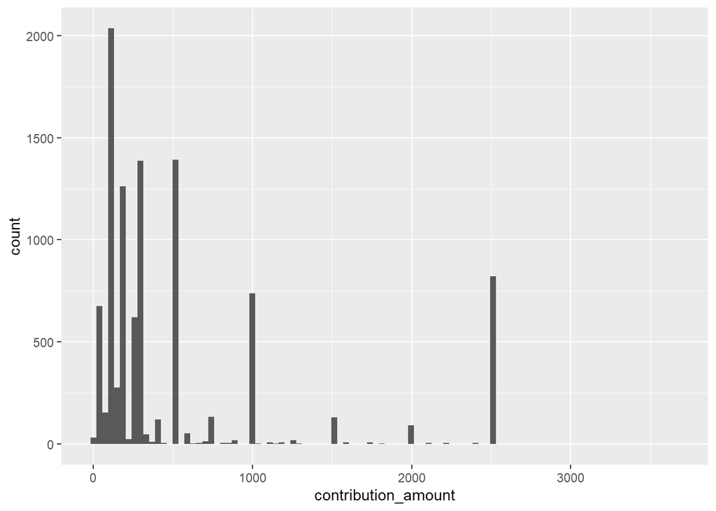

```r
cand_rels <- mayorcamp2014 %>% select(relationship_to_candidate) %>% unique()
mayorcamp2014_nocand <- mayorcamp2014 %>% filter(relationship_to_candidate == "Spouse" | is.na(relationship_to_candidate))
mayorcamp2014_nocand %>% ggplot(aes(x=contribution_amount)) + geom_histogram(bins = 100)
```

```r
mayorcamp2014_nocand %>% group_by(candidate) %>%
  summarise(total_contributions = sum(contribution_amount, na.rm=TRUE)) %>%
  arrange(desc(total_contributions)) %>%
  slice(1:5)
```

| candidate | total_contributions |
| --- | --- |
| Tory, John | 2765368.7 |
| Chow, Olivia | 1635765.9 |
| Ford, Doug | 331172.6 |
| Stintz, Karen | 242805.0 |
| Ford, Rob | 174509.5 |

```r
mayorcamp2014_nocand %>% group_by(candidate) %>%
  summarise(mean_contributions = mean(contribution_amount, na.rm=TRUE)) %>%
  arrange(desc(mean_contributions)) %>%
  slice(1:5)
```

| candidate | mean_contributions |
| --- | --- |
| Ritch, Carlie | 1886.667 |
| Sniedzins, Erwin | 1866.667 |
| Tory, John | 1063.194 |
| Gardner, Norman | 1000.000 |
| Tiwari, Ramnarine | 1000.000 |

```r
mayorcamp2014_nocand %>% group_by(candidate) %>%
  summarise(number_contributions = n()) %>%
  arrange(desc(number_contributions)) %>%
  slice(1:5)
```

| candidate | number_contributions |
| --- | --- |
| Chow, Olivia | 5707 |
| Tory, John | 2601 |
| Ford, Doug | 608 |
| Ford, Rob | 531 |
| Soknacki, David | 314 |

8. How many contributors gave money to more than one candidate?

```r
mayorcamp2014 %>% group_by(contributors_name) %>%
  summarise(n_candidates = n_unique(candidate)) %>%
  filter(n_candidates > 1) %>%
  summarise(num_contributors = n())
```

| num_contributors |
| --- |
| 184 |